# Profilowanie obciążenia korytarzy transportowych A1/S8 w celu optymalizacji pracy centrum dystrybucyjnego

**Problem badawczy:** Jak cykl tygodniowy oraz zmienność kalendarzowa wpływają na ruch ciężarowy na korytarzach A1 i S8? Celem analizy jest identyfikacja wzorców ruchu na Węźle Łódź Południe, stanowiącym główne okno logistyczne dla centrum w Rzgowie, oraz ocena ryzyka zatorów.

**Założenie analityczne (Scope Definition):** W celu zapewnienia wysokiej jakości wniosków operacyjnych, zbiór danych z systemu e-TOLL został zawężony wyłącznie do dni roboczych (poniedziałek-piątek). Pozwala to na wyeliminowanie szumu informacyjnego z weekendów i skupienie się na potokach ciężarowych istotnych dla procesów magazynowych.

# Analiza Dzienna

### Import bibliotek i konfiguracja środowiska

```python
import pandas as pd
import matplotlib.pyplot as plt
import seaborn as sns

# Paleta IBCS do raportowania biznesowego
ibcs_palette = ['#000000', '#333333', '#555555', '#777777', '#999999', '#AAAAAA', '#BBBBBB', '#CCCCCC', '#DDDDDD', '#EEEEEE']
sns.set_style("ticks")

# Wczytanie danych
df_drogi_dzienny = pd.read_csv('data/pojazdy_wg_numeru_drogi_dzienna.csv', sep=',')

# Konwersja dat
df_drogi_dzienny['Data'] = pd.to_datetime(df_drogi_dzienny['Data'])

# Mapowanie dni tygodnia
dni_tygodnia_mapa = {
    'Monday': 'Poniedziałek', 'Tuesday': 'Wtorek', 'Wednesday': 'Środa',
    'Thursday': 'Czwartek', 'Friday': 'Piątek', 'Saturday': 'Sobota', 'Sunday': 'Niedziela'
}
df_drogi_dzienny['Dzień_tygodnia_pl'] = df_drogi_dzienny['Data'].dt.day_name().map(dni_tygodnia_mapa)

kolejnosc_dni = ['Poniedziałek', 'Wtorek', 'Środa', 'Czwartek', 'Piątek', 'Sobota', 'Niedziela']
df_drogi_dzienny['Dzień_tygodnia_pl'] = pd.Categorical(
    df_drogi_dzienny['Dzień_tygodnia_pl'],
    categories=kolejnosc_dni,
    ordered=True
)
```

### Definicja Zakresu Analizy

```python
# Filtrowanie do dni roboczych
df_robocze = df_drogi_dzienny[df_drogi_dzienny['Dzień_tygodnia_pl'].isin(['Poniedziałek', 'Wtorek', 'Środa', 'Czwartek', 'Piątek'])].copy()

# Usunięcie pustych kategorii (Sobota, Niedziela), aby nie psuły osi wykresów
df_robocze['Dzień_tygodnia_pl'] = df_robocze['Dzień_tygodnia_pl'].cat.remove_unused_categories()

print("Struktura danych operacyjnych (dni robocze):")
display(df_robocze.head())
```

```
Struktura danych operacyjnych (dni robocze):
```

|  | Data | Numer drogi | Wartość | Dzień_tygodnia_pl |
| --- | --- | --- | --- | --- |
| 0 | 2021-10-01 | A1 | 32352 | Piątek |
| 3 | 2021-10-04 | A1 | 38838 | Poniedziałek |
| 4 | 2021-10-05 | A1 | 39463 | Wtorek |
| 5 | 2021-10-06 | A1 | 39543 | Środa |
| 6 | 2021-10-07 | A1 | 40223 | Czwartek |

### Analiza Zależności tras (Korelacja)

```
Korelacja upływu tygodnia roboczego do natężenia ruchu: -0.13
```

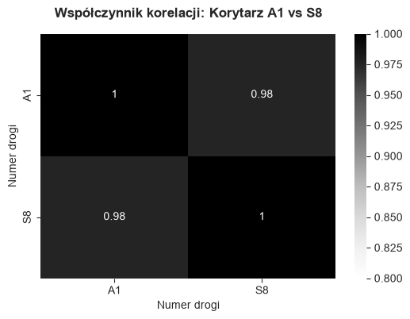

```python
# Korelacja Dzień vs Ruch (spadek/wzrost w trakcie tygodnia roboczego)
df_robocze['Dzien_Num'] = df_robocze['Dzień_tygodnia_pl'].cat.codes
korelacja_dzien = df_robocze['Dzien_Num'].corr(df_robocze['Wartość'])
print(f"Korelacja upływu tygodnia roboczego do natężenia ruchu: {korelacja_dzien:.2f}")

# Heatmapa A1 vs S8
plt.figure(figsize=(6, 4))
df_pivot = df_robocze.pivot(index='Data', columns='Numer drogi', values='Wartość')
sns.heatmap(df_pivot.corr(), annot=True, cmap='Greys', vmin=0.8, vmax=1.0)
plt.title('Współczynnik korelacji: Korytarz A1 vs S8', pad=15, fontweight='bold')
plt.show()
```

**Wniosek biznesowy:** Brak silnej korelacji (-0.13) oraz wyrównane poziomy na wykresie słupkowym dowodzą, że ruch roboczy jest wysoce stabilny. Rekomenduje to wdrożenie tzw. płaskiego harmonogramu pracy na rampach w Rzgowie, bez konieczności codziennego, kosztownego manipulowania liczbą personelu.  
**Wniosek biznesowy:** Ekstremalnie wysoka korelacja (0.98) udowadnia, że trasy A1 i S8 reagują identycznie na sytuację makroekonomiczną i drogową. Korytarze te nie dają możliwości dywersyfikacji ryzyka – w przypadku zatorów firma musi przygotować się na opóźnienia z obu kierunków jednocześnie.